# Wine Quality Reds by Heidi Raasch

This report explores a dataset containing information on the relationship between red wine attributes and quality.

# Univariate Plots Section

```
## Observations: 1,599
## Variables: 13
## $ X                    <int> 1, 2, 3, 4, 5, 6, 7, 8, 9, 10, 11, 12, 13...
## $ fixed.acidity        <dbl> 7.4, 7.8, 7.8, 11.2, 7.4, 7.4, 7.9, 7.3, ...
## $ volatile.acidity     <dbl> 0.700, 0.880, 0.760, 0.280, 0.700, 0.660,...
## $ citric.acid          <dbl> 0.00, 0.00, 0.04, 0.56, 0.00, 0.00, 0.06,...
## $ residual.sugar       <dbl> 1.9, 2.6, 2.3, 1.9, 1.9, 1.8, 1.6, 1.2, 2...
## $ chlorides            <dbl> 0.076, 0.098, 0.092, 0.075, 0.076, 0.075,...
## $ free.sulfur.dioxide  <dbl> 11, 25, 15, 17, 11, 13, 15, 15, 9, 17, 15...
## $ total.sulfur.dioxide <dbl> 34, 67, 54, 60, 34, 40, 59, 21, 18, 102, ...
## $ density              <dbl> 0.9978, 0.9968, 0.9970, 0.9980, 0.9978, 0...
## $ pH                   <dbl> 3.51, 3.20, 3.26, 3.16, 3.51, 3.51, 3.30,...
## $ sulphates            <dbl> 0.56, 0.68, 0.65, 0.58, 0.56, 0.56, 0.46,...
## $ alcohol              <dbl> 9.4, 9.8, 9.8, 9.8, 9.4, 9.4, 9.4, 10.0, ...
## $ quality              <int> 5, 5, 5, 6, 5, 5, 5, 7, 7, 5, 5, 5, 5, 5,...
```

X appears to be a index for each row of the data. Therefore, we will exclude that variable going foward.

#Examine histograms of all variables

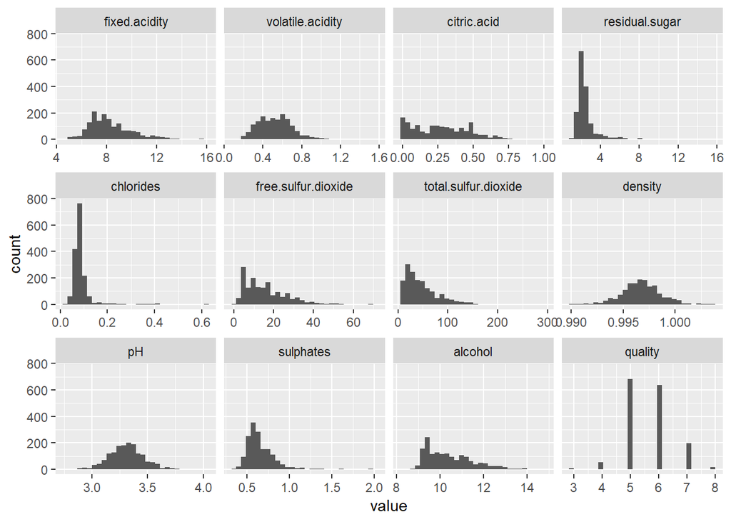

We can see that most of the variables have a normal distribution. There are outliers in the residual.sugar, sulphates and chlorides variables that make it difficult to properly view the distribution. To make the distributions of these 3 variables easier to see we will exclude the 95 percentile.

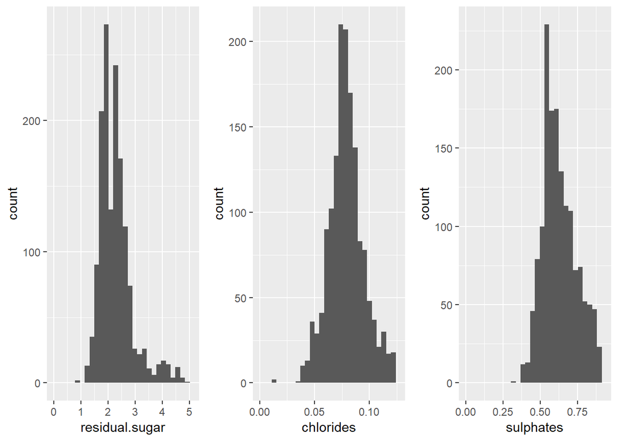

We can also see that there is a problem with the quality plot. We do not want there to be spaces between the bars on the hisograms as that can indicate a possiblitity of observations between the bars. Therefore we will use a bar plot instead of the histogram.

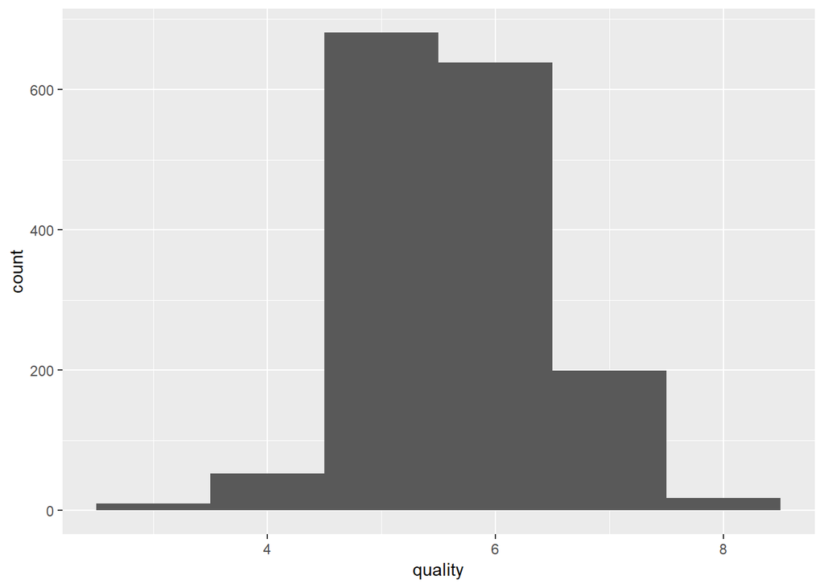

After removing the outliers we can see the distributions of residual.sugar, chlorides, and sulphates are also normal.

I am most interested in the quality of the wines and what variables have an impact on the quality.

#Quality

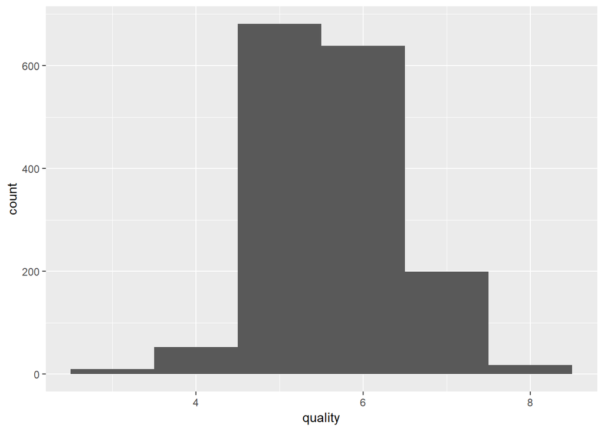

The majority of the wines are of average quality (4.5-6.5) and there are few wines with low or high quality. The lowest quality is 3 and the highest quality is 8.

#PH

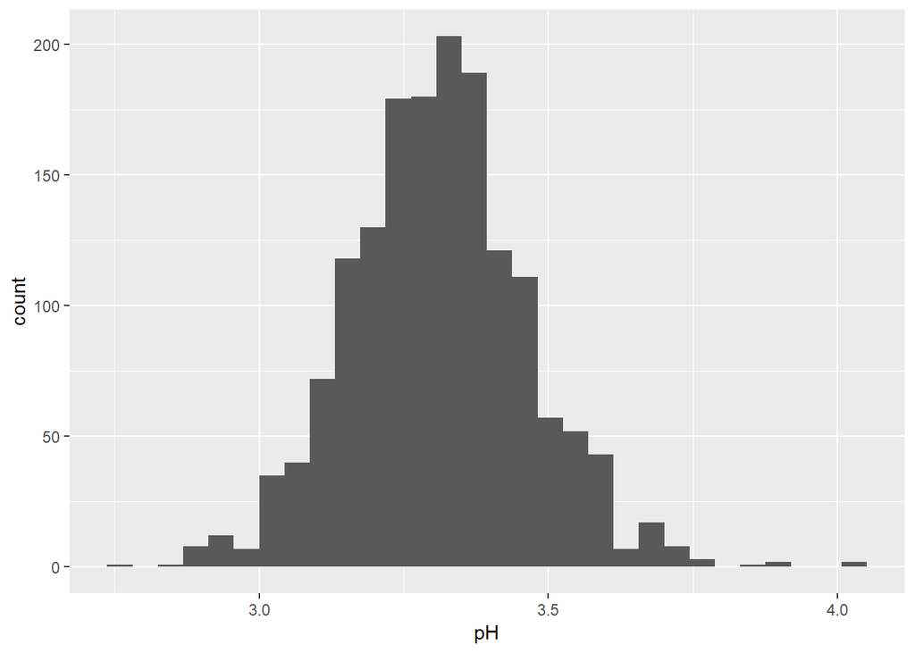

The distribution of the pH of the wines is similar to the distribution of the quality of the wines. It is a normal distribution with a majority of the wines having a pH between 3.0 and 3.7 with a few wines having a pH higher than 3.7 or lower than 3.0.

#Alcohol

Alcohol is another important factor of red wines. I will explore that next.

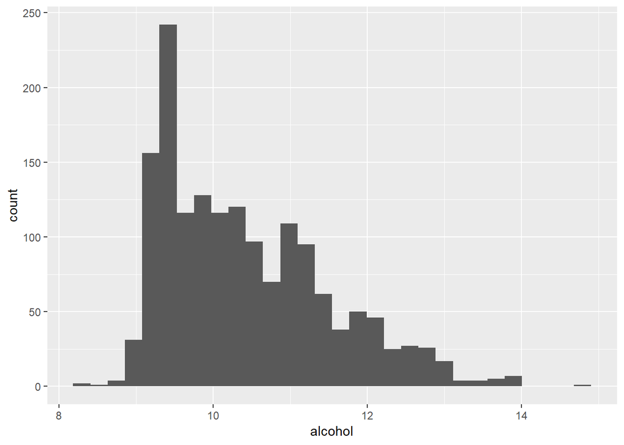

Unlike pH and qality we see that alcohol is right skewed. We see a majority of the wines have an alcohol content that falls on the left side of the plot.

# Univariate Analysis

### What is the structure of your dataset?

The dataset has 12 variables representing 1599 observations. Each observation corresponds to a red wine sample. 11 of the variables correspond to the result of a physicochemical test and the last variable (quality) corresponds to the result of a sensory panel rating.

### What is/are the main feature(s) of interest in your dataset?

The main feature of interest in this dataset is quality.

### What other features in the dataset do you think will help support your

investigation into your feature(s) of interest?

Each of the physicochemical variables will help support the investigation as they each can impact the taste and quality of the wine. Also, I expect that some of the variables will have a high correlation to each other.

### Did you create any new variables from existing variables in the dataset?

I created the meltData variable which made use of the reshape library to melt the wide data.

### Of the features you investigated, were there any unusual distributions?

Did you perform any operations on the data to tidy, adjust, or change the form  
of the data? If so, why did you do this?

Originally the residual.sugar, sulphates and chlorides variables had skewed distributions that contained outliers. I excluded the 95th percentile to remove the outliers which resulted in normal distributions.

# Bivariate Plots Section

The correlations between each of the variables and quality are: Fixed Acidity: 0.1240516 Volatile Acidity: -0.3905578 Citric Acid: 0.2263725 Residual Sugar: 0.01373164 Chlorides: -0.1289066 Free Sulfur Dioxide:-0.05065606 Density: -0.1749192  
pH: -0.05773139 Sulphates: 0.2513971 Alcohol: 0.4761663

The top 4 correlation coefficents to the quality of the wine are: Alcohol: 0.48 Sulphates: 0.25 Citric Acid: 0.23 Fixed Acidity: 0.12

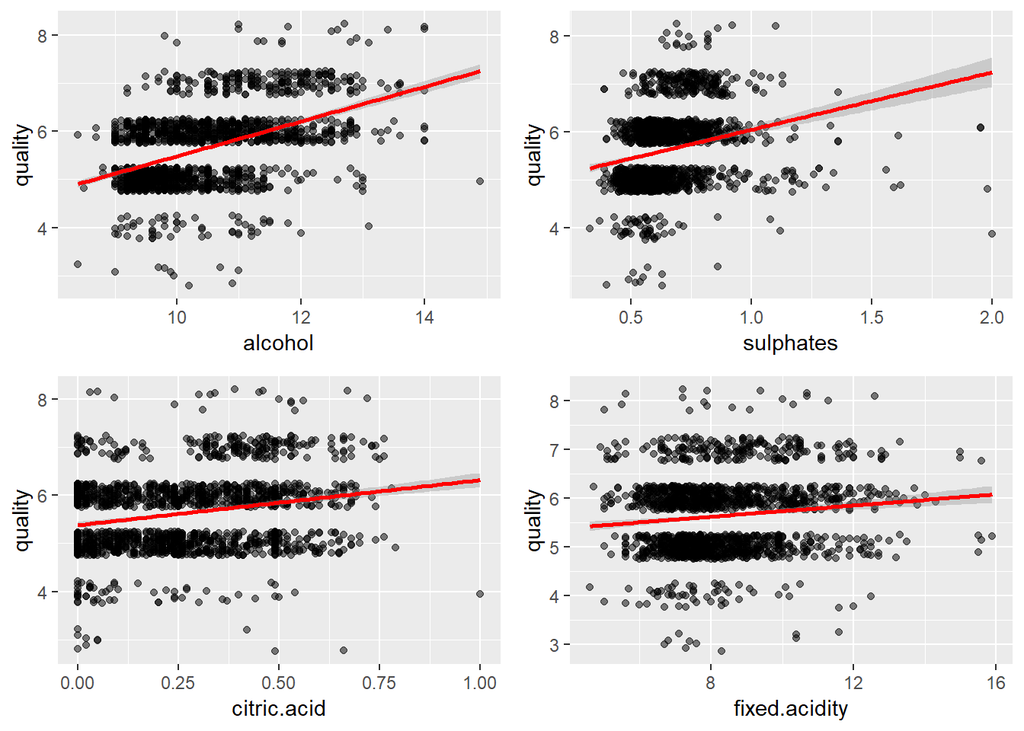

We can see that the quality of the wine increases with as the alcohol, sulphates, citric acid, and fixed acidity increase.

Lets take a look at some of the correlations between alcohol and some of the other variables.

The correlations between each of the variables and alcohol are: Fixed Acidity: -0.06166827 Volatile Acidity: -0.202288 Citric Acid: 0.1099032 Residual Sugar: 0.04207544 Chlorides: -0.2211405 Free Sulfur Dioxide: -0.06940835 Density: -0.4961798  
pH: 0.2056325 Sulphates: 0.09359475

The variables with the highest (positive or negative) correlations are: Density: -0.50 Chlorides: -0.22 pH: 0.21 Volatile Acidity: -0.20

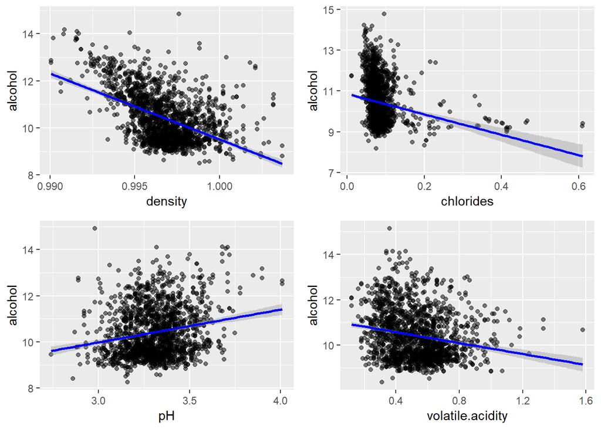

We can see that the density, chlorides, and volatile acidity of the wine decrease with the amount of alcohol in the wine. Whereas the pH tends to increase with the amount of alcohol.

Lets explore the correlation between pH, citric acid, volatile acidity, and fixed acidity.

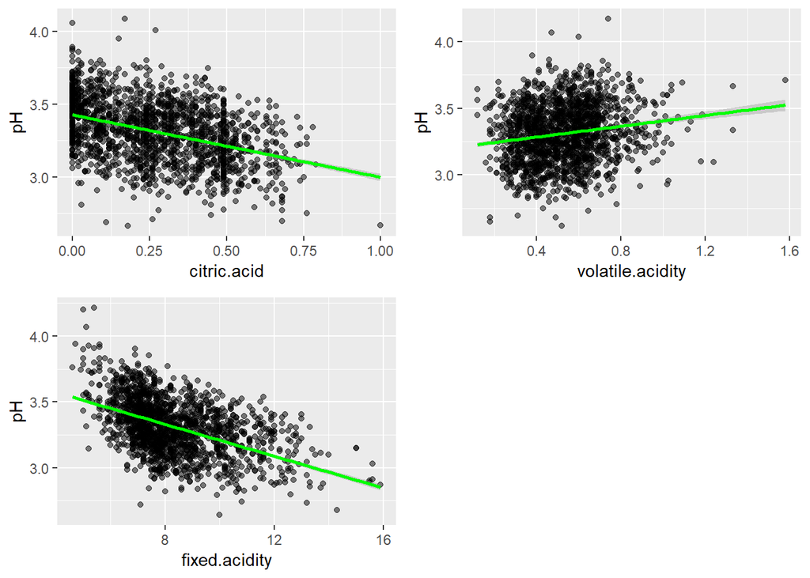

Here we can see that the pH decreases as the citric acid and fixed acidity increase whereas the pH increases as the volatile acidity increases.

# Bivariate Analysis

### Talk about some of the relationships you observed in this part of the

investigation. How did the feature(s) of interest vary with other features in  
the dataset?

The quality of the wine increases with as the alcohol, sulphates, citric acid, and fixed acidity increase.

The density, chlorides, and volatile acidity of the wine decrease with the amount of alcohol in the wine. Whereas the pH tends to increase with the amount of alcohol.

The pH decreases as the citric acid and fixed acidity increase whereas the pH increases as the volatile acidity increases.

### Did you observe any interesting relationships between the other features

(not the main feature(s) of interest)?

I found it interesting that the density decreases with the amount of alcohol in the wine.

### What was the strongest relationship you found?

# Multivariate Plots Section

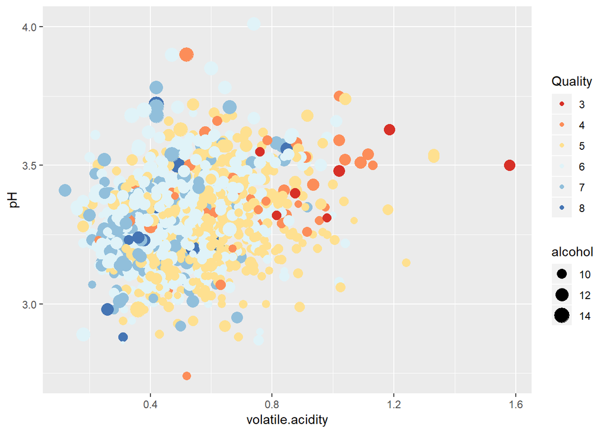

We see that a higher concentration of the blue dots are located on the left side of the plot. This indicates the higher quality wines have lower volatile acidity. This is also where we see the larger dots representing the wines with a higher alcohol content.

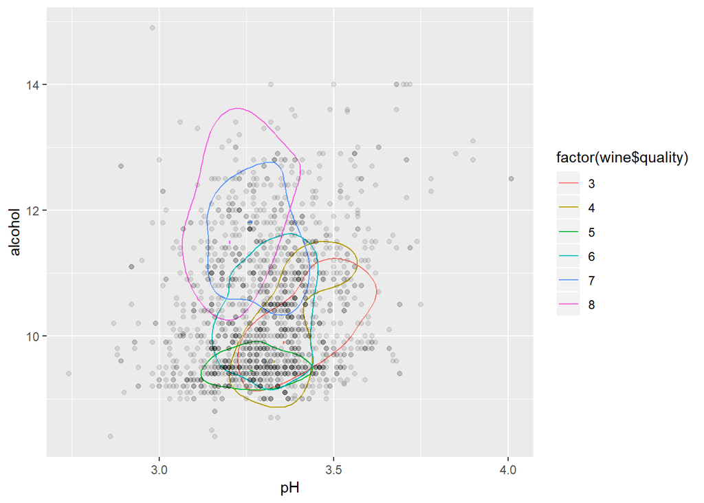

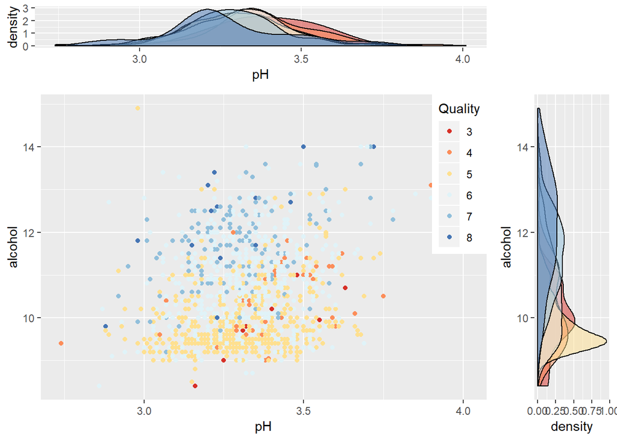

# Multivariate Analysis

### Talk about some of the relationships you observed in this part of the

investigation. Were there features that strengthened each other in terms of  
looking at your feature(s) of interest?

The main relationshps explored were between the pH and alcohol content.

### Were there any interesting or surprising interactions between features?

The relationship between pH and alcohol is interesting.

# Final Plots and Summary

### Plot One

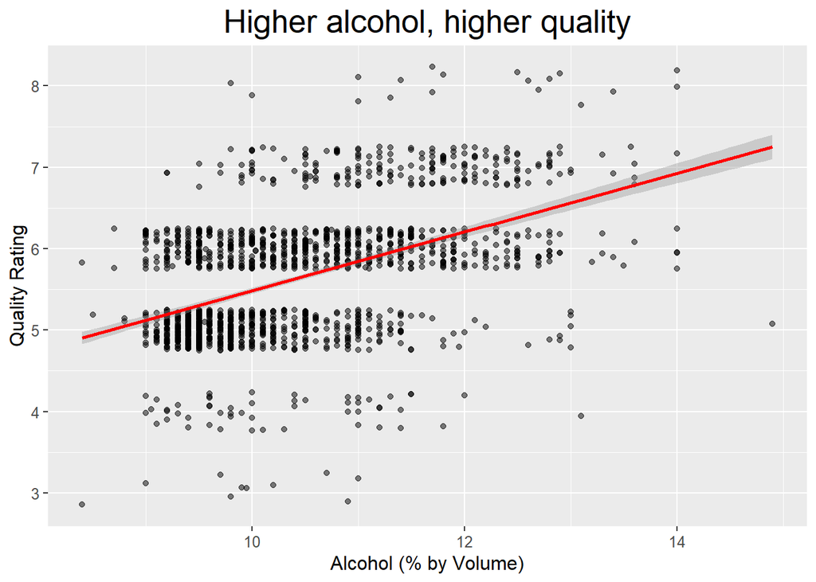

### Description One

This plot demonstrates how the quality of a wine increases as the alcohol content increase. We see a high concentration of the points in the middle of the quality axis.

### Plot Two

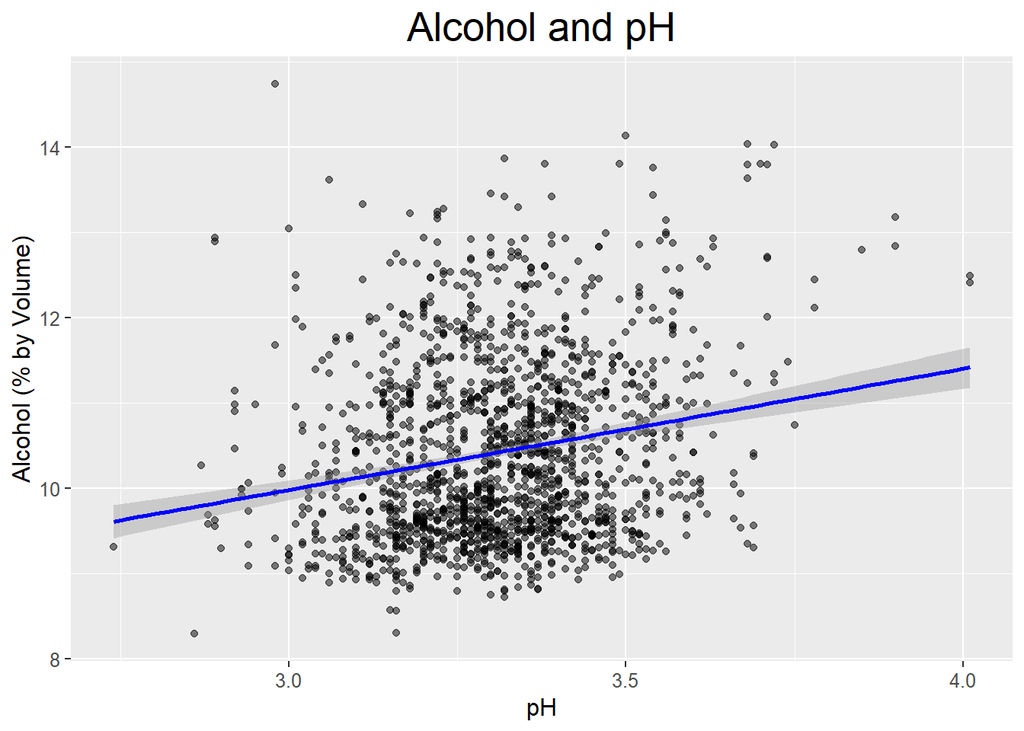

### Description Two

This plot shows the relationship between pH and Alcohol. We see that the pH slightly increases as the alcohol content gets higher. We can also see how the points are more spread out as the alcohol content gets higher and they get more condensed the lower the alcohol content is.

### Plot Three

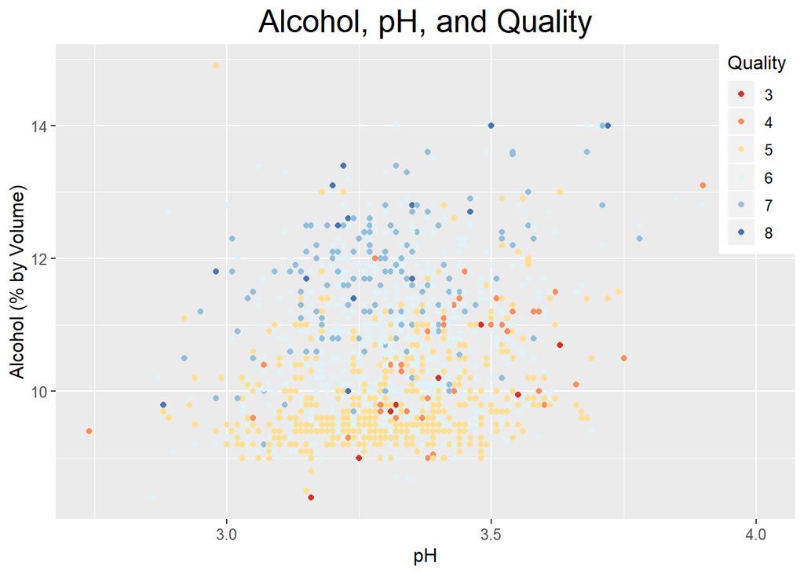

### Description Three

# Reflection

This project was interesting as I was able to put my new found knowledge of the plotting functionality of R to the test on a real dataset. There are several ways I could have gone with this data and I found it difficult trying to narrow down my exploration. This dataset was already clean which made it easy to work with.

Future work with this dataset could include combining the white wine dataset with this dataset to find if there are differences when it comes to red vs white wines.